# Symulacje Monte Carlo i Bootstraping w środowisku R (234240-D)

Lab #4

Uladzislau Darhevich

2021-12-07

# 1. Ciągi o niskiej dyskrepancji. Algorytmy Haltona i Sobola generowania ciągów w R.

## Zadanie:

- Korzystając z bibiloteki `randtoolbox` znajdź funkcję do generowania ciągów o niskiej rozbieżności
- Porównaj ciągi (wykresy)
- Korzystając z bibiloteki `fOptions` znajdź funkcję do generowania ciągów o niskiej rozbieżności o rozkładzie….
- Rozszerz funkcję wyceny opcji o dwa dodatkowe generatory ciągów

Generowanie ciągów Haltona, Sobol’a oraz ciągów z rozkładem jednostajnym za pomocą `randtoolbox`

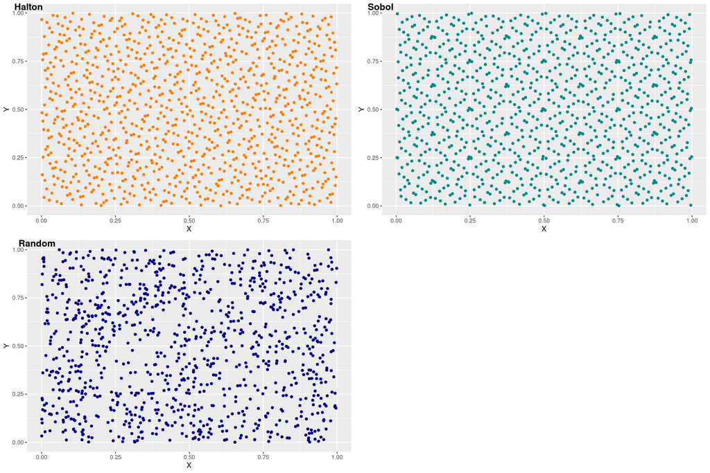

```r
h <- halton(1000, 2)
s <- sobol(1000, 2)
r <- matrix(runif(2000), nrow = 1000, ncol = 2)
df <- data.frame(unlist(h), unlist(s), unlist(r))
names(df) <- c("Halton1", "Halton2", "Sobol1", "Sobol2", "Random1", "Random2")
img1 <- ggplot(df, aes(x=Halton1, y=Halton2)) +
  geom_point(color='darkorange1') +
  xlab("X") + ylab("Y")
img2 <- ggplot(df, aes(x=Sobol1, y=Sobol2)) +
  geom_point(color='darkcyan') +
  xlab("X") + ylab("Y")
img3 <- ggplot(df, aes(x=Random1, y=Random2)) +
  geom_point(color='darkblue') +
  xlab("X") + ylab("Y")
img <- ggarrange(img1, img2, img3,
          labels = c("Halton", "Sobol", "Random"),
          ncol = 2, nrow = 2)
print(img)
```

Generowanie ciągów Haltona, Sobol’a oraz ciągów z rozkładem jednostajnym za pomocą `fOptions`

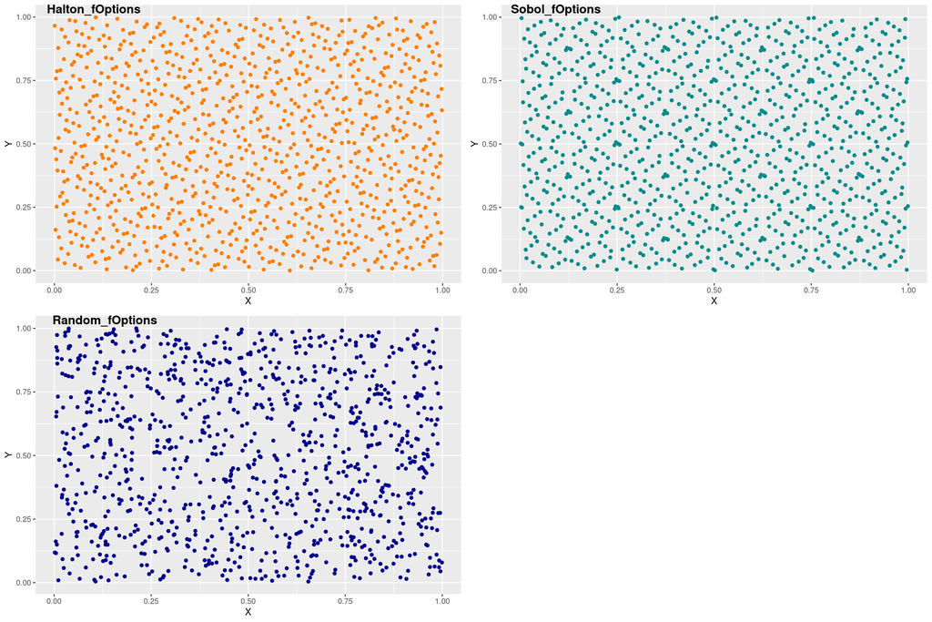

```r
h1 <- runif.halton(1000, 2)
s1 <- runif.sobol(1000, 2)
r1 <- matrix(runif.pseudo(2000, 2), nrow = 1000, ncol = 2)
df1 <- data.frame(unlist(h1), unlist(s1), unlist(r1))
names(df1) <- c("Halton1", "Halton2", "Sobol1", "Sobol2", "Random1", "Random2")
img1 <- ggplot(df1, aes(x=Halton1, y=Halton2)) +
  geom_point(color='darkorange1') +
  xlab("X") + ylab("Y")
img2 <- ggplot(df1, aes(x=Sobol1, y=Sobol2)) +
  geom_point(color='darkcyan') +
  xlab("X") + ylab("Y")
img3 <- ggplot(df1, aes(x=Random1, y=Random2)) +
  geom_point(color='darkblue') +
  xlab("X") + ylab("Y")
img <- ggarrange(img1, img2, img3,
          labels = c("Halton_fOptions", "Sobol_fOptions", "Random_fOptions"),
          ncol = 2, nrow = 2)
print(img)
```

```r
prices <- c(196, 161, 170)
calls <- NULL
puts <- NULL
for (i in prices){
  tmp <- GBSOption(TypeFlag = "c", S = i, X = 184, Time = 3/52, r = 0.03,
                   b = 0.03, sigma = 0.20)@price
  calls <- rbind(calls, tmp)
  tmp <- GBSOption(TypeFlag = "p", S = i, X = 184, Time = 3/52, r = 0.03,
                   b = 0.03, sigma = 0.20)@price
  puts <- rbind(puts, tmp)
}
df <- data.frame(unlist(prices), unlist(calls), unlist(puts))
names(df) <- c("Cena opcji, PLN", "CALL", "PUT")
rownames(df) <- df$prices
pander(df, type = 'grid')
```

| Cena opcji, PLN | CALL | PUT |
| --- | --- | --- |
| 196 | 12.69 | 0.3717 |
| 161 | 0.007582 | 22.69 |
| 170 | 0.192 | 13.87 |

# 2. Kopule

## Zadanie:

- Wczytaj dwa szeregi czasowe.
- Korzystając z bibiloteki `VineCopula` znajdź funkcję do estymacji parametrów i rodzaju kopuli.
- Porównaj parametry korzystając z pakietu `copula`
- Narysuj wykres kopuli.
- Korzystając z parametrów zasymuluj n prób.
- Wyznacz współczynnik korelacji Kendalla.

Jako szeregi czasowe weźmy dane o cenach akcji (*adjusted closing price*) dla dwóch firm produkujących podobne towary: *DELL* oraz *HPE* za ostatnie 1000 dni

```r
first.date <- Sys.Date() - 1000
last.date <- Sys.Date()
freq.data <- 'daily'
tickers <- c('HPE', 'DELL')
#pobieranie danych
l.out <- BatchGetSymbols(tickers = tickers,
                         first.date = first.date,
                         last.date = last.date,
                         freq.data = freq.data,
                         cache.folder = file.path(tempdir(),
                                                  'BGS_Cache'))

df <- l.out$df.tickers
df <- df %>% select(ref.date, ticker, price.adjusted)
df <- spread(df, ticker, price.adjusted)
```

Korzystając z bibiloteki `VineCopula` użyjmy funkcję `BiCopSelect` do estymacji parametrów i rodzaju kopuli. Do algorytmu selekcji trzeba prowadzić pseudo obserwacje za pomocą funkcji `pobs()`. Pseudo obserwacje to obserwacje w przedziale [0,1].

```r
hpe <- pobs(df)[, 2]
dell <- pobs(df)[, 3]
m <- as.matrix(cbind(hpe,dell))
selectedCopula <- BiCopSelect(hpe, dell, familyset = NA)
par_1 <- selectedCopula$par
pander(selectedCopula)
```

- **family**: *1*
- **par**: *0.5311*
- **par2**: *0*
- **npars**: *1*
- **familyname**: Gaussian
- **tau**: *0.3564*
- **beta**: *0.3564*
- **taildep**:
  - **lower**: *0*
  - **upper**: *0*
- **call**: `BiCopSelect(u1 = hpe, u2 = dell, familyset = NA)`
- **nobs**: *691*
- **logLik**: *112*
- **AIC**: *-222*
- **BIC**: *-217.5*
- **emptau**: *0.3552*
- **p.value.indeptest**: *0*

Według estymacji optymalną kopulą będzie kopula Gaussa. Spróbujmy dopasować sugerowany model za pomocą pakietu `copula` i dokładnie sprawdzić dopasowane parametry.

```r
gauss_cop <- normalCopula(dim=2)
fit <- fitCopula(gauss_cop, m, method='ml')
par_2 <- coef(fit)
```

Parameter `par` według `BiCopSelect` wynosi 0.531105, według `fitCopula` wynosi 0.5310894.

Po zamontowaniu kopuły możemy sprawdzić, czy dopasowanie jest dobre, czy nie. Aby wykonać ten test GOF, możemy użyć funkcji `gofcopula()` jak poniżej.

```r
gf <- gofCopula(gauss_cop, m, N = 50)
pander(gf)
```

Parametric bootstrap-based goodness-of-fit test of Normal copula, dim. d = 2, with ‘method’=“Sn”, ‘estim.method’=“mpl”:: `x`

| Test statistic | parameter | P value |
| --- | --- | --- |
| 0.3372 | 0.5311 | 0.009804 * * |

Zasymulujmy 10000 prób korzystając z parametrów i zróbmy wykresy

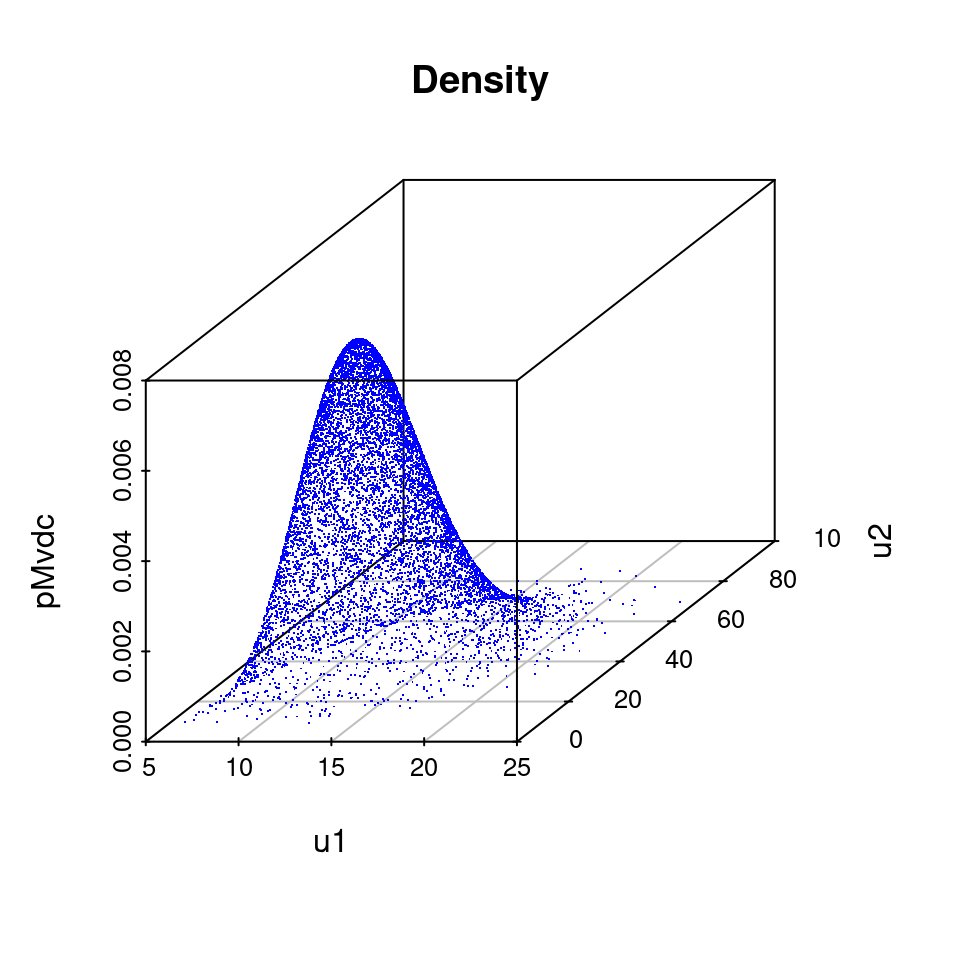

```r
x_mean <- mean(df$HPE)
x_var <- var(df$HPE)
x_rate <- x_mean / x_var
x_shape <- ((x_mean)^2) / x_var

y_mean <- mean(df$DELL)
y_var <- var(df$DELL)
y_rate <- y_mean / y_var
y_shape <- ((y_mean)^2) / y_var


my_dist <- mvdc(normalCopula(par_2, dim=2),
                margins = c("gamma","gamma"),
                paramMargins = list(list(shape = x_shape,
                                         rate = x_rate),
                              list(shape = y_shape,
                                   rate = y_rate)
                                    )
                )
v <- rMvdc(10000, my_dist)
pdf_mvd <- dMvdc(v, my_dist) #gęstość
cdf_mvd <- pMvdc(v, my_dist) #dystrybuanta

img1 <- scatterplot3d(v[, 1], v[, 2],
                      pdf_mvd,
                      color="blue",
                      main="Density",
                      xlab = "u1",
                      ylab="u2",
                      zlab="pMvdc",
                      pch=".")
```

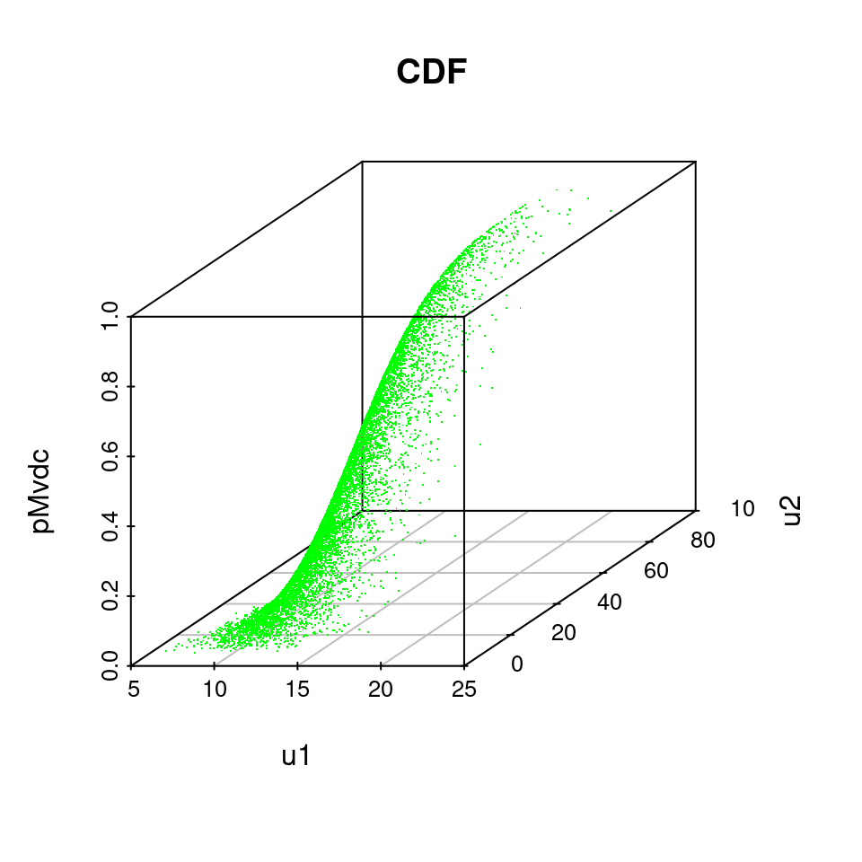

```r
img2 <- scatterplot3d(v[, 1],v[, 2],
                      cdf_mvd,
                      color="green",
                      main="CDF",
                      xlab = "u1",
                      ylab="u2",
                      zlab="pMvdc",
                      pch=".")
```

Współczynnik korelacji Kendalla wynosi:

|  | hpe | dell |
| --- | --- | --- |
| **hpe** | 1 | 0.3552 |
| **dell** | 0.3552 | 1 |